# Niche overlap increases with increasing resource availability in a tropical plant-pollinator network.

Ben Weinstein

Tuesday, October 14, 2014

# Aim

Which birds use which plants? What are the mechanisms that determine niche overlap in this assemblage.

We will fit several difference types of models and ask how they inform our understanding. For each model, we try to calculate a measure of discrepancy and assess model fit.

## Data

- Using automated cameras and transects, we have been recording flower visitation rates by each hummingbird species for two years.
- We have bill and corolla lengths for each species of bird and flower.
- We have been collecting phenology data on available resources

Birds use flowers that have similar length of bill shape and we expect the importance of trait matching to decrease as available resources increase.

# Read in Data

```
## [1] "Orange-crowned Euphonia"   "White-lined Flowerpiercer"
```

```
##  [1] "Missing Trait Information: Burmeistera cylindrocarpa"
##  [2] "Missing Trait Information: Burmeistera multiflora"
##  [3] "Missing Trait Information: Calathea ischnosiphonoides"
##  [4] "Missing Trait Information: Canna jaegeriana"
##  [5] "Missing Trait Information: Cavendishia tarapotana"
##  [6] "Missing Trait Information: Centropogon nigricans"
##  [7] "Missing Trait Information: Drymonia brochidodroma"
##  [8] "Missing Trait Information: Drymonia collegarum"
##  [9] "Missing Trait Information: Gasteranthus pansamalanus"
## [10] "Missing Trait Information: Guzmania fusispica"
## [11] "Missing Trait Information: Guzmania lehmanniana"
## [12] "Missing Trait Information: Guzmania squarrosa"
## [13] "Missing Trait Information: Hydrangea peruviana"
## [14] "Missing Trait Information: Justicia secunda"
## [15] "Missing Trait Information: Mikania websteri"
## [16] "Missing Trait Information: Palicourea sodiroi"
## [17] "Missing Trait Information: Pitcairnia nigra"
## [18] "Missing Trait Information: Psammisia ecuadorensis"
```

# Available Resources

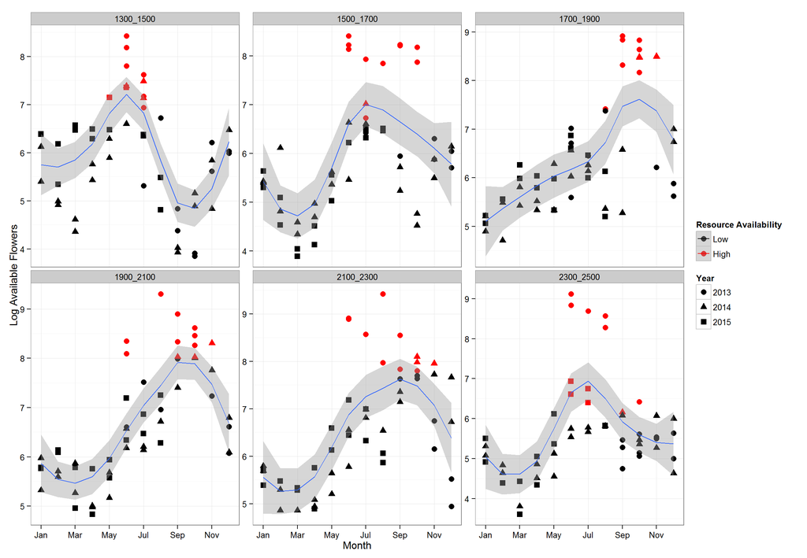

### What is the temporal distribution of resources?

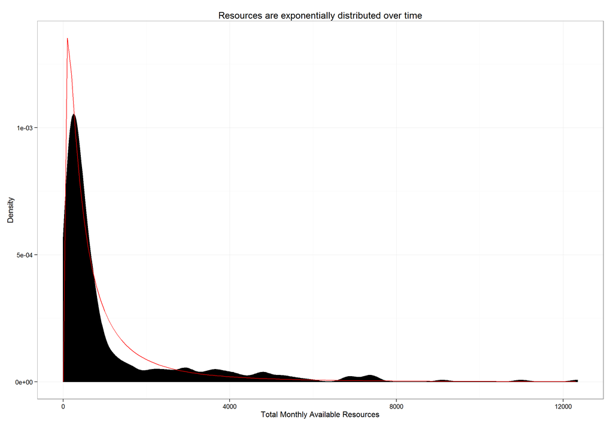

## Match Species to Morphology

### Elevation ranges

Create a binary variable whether each observation was in a low elevation or high elevation transect. We have some species that just occur at the top of the gradient, and are not present in the sampling window of flowers at the low elevation.

Accounting for non-availability. We have to figure out which plants were sampled in which periods, and if it was sampled, the non-detection are 0 if it wasn’t the non-detection are NA. then remove all the Na’s.

```
##                 Hummingbird  Low        m High Index
## 1   Green-crowned Woodnymph 1359 1376.645 1390     1
## 2 Rufous-tailed Hummingbird 1368 1476.333 1380     1
## 3            Andean Emerald 1378 1386.261 1380     1
## 4      White-necked Jacobin 1368 1397.500 1422     1
## 5    Stripe-throated Hermit 1368 1440.887 1450     1
## 6    White-whiskered Hermit 1340 1412.391 1450     1
```

What elevation transect is each observation in?

## Resource availability at each data point

# Absences - accounting for non-detection

We have more information than just the presences, given species elevation ranges, we have absences as well. Absences are birds that occur at the elevation of the plant sample, but were not recorded feeding on the flower.

## Elevation ranges

How much do the bird and plant elevation range match? Using the transect data we will take the absolute value of the difference in mean elevation for each species pair.

## Exploratory model fitting

Generalized models for the predictors. Does not account for detection rates, and does not account for non-independence of observations.

## Occurrence as a function of traits

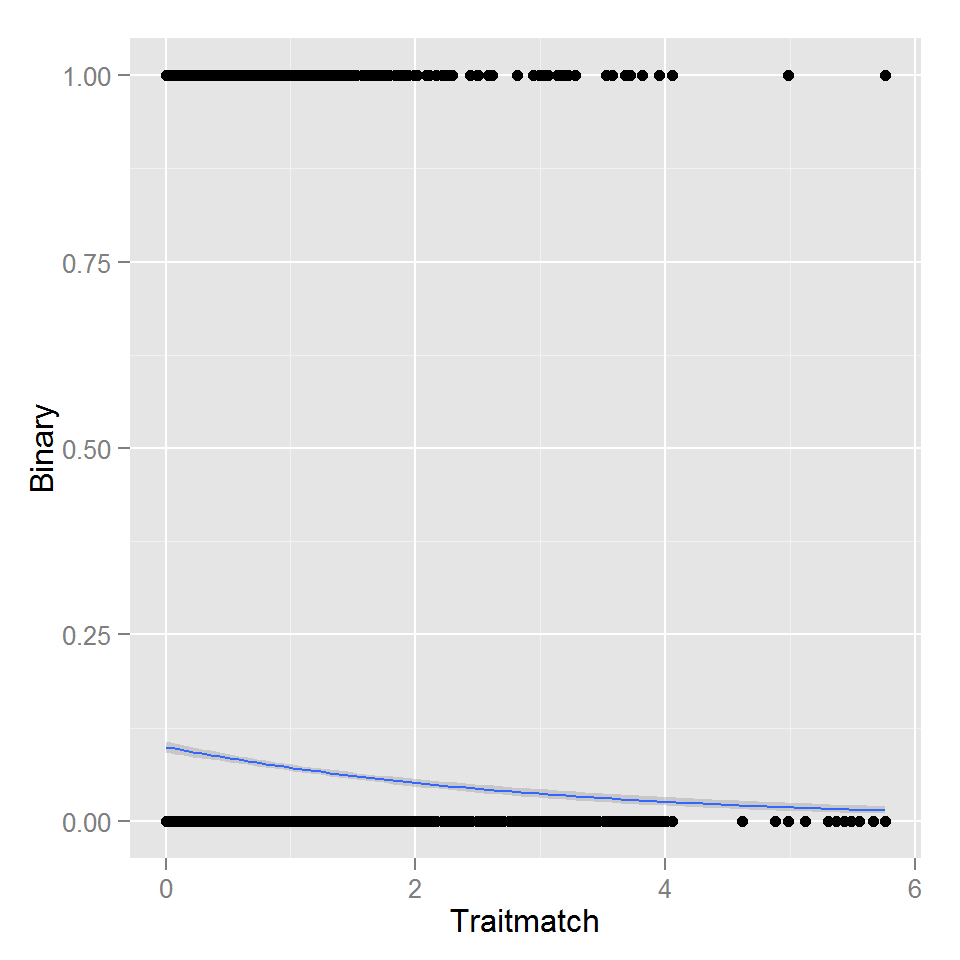

## Occurrence as a function of resources

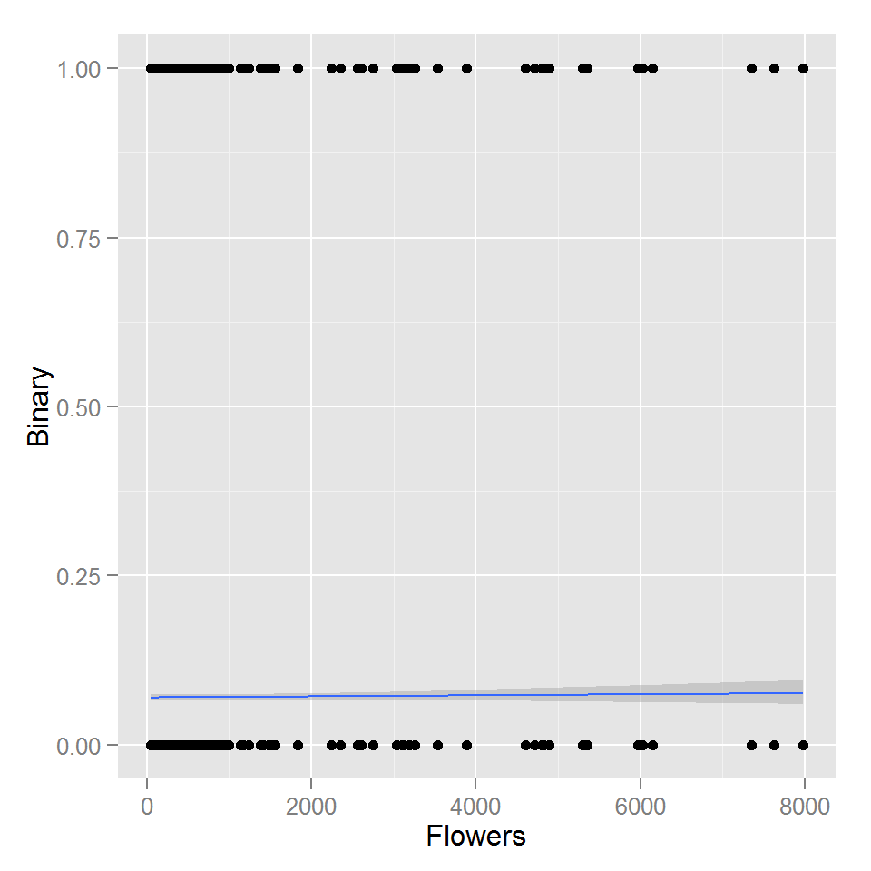

## Occurrence as a function of elevation range

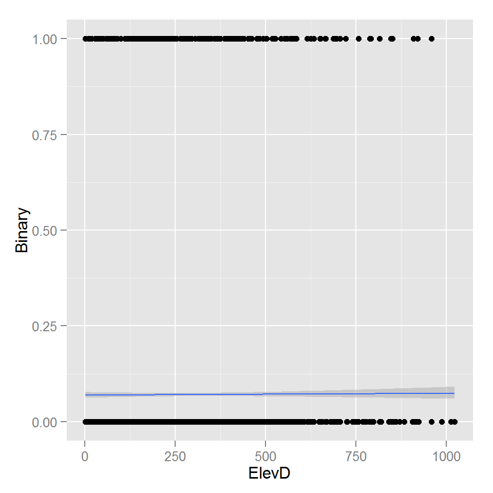

## Mixed Effect models with non-detections

```
## Data: obsf
## Models:
## traitonly: Binary ~ Traitmatch + (1 | Bird)
## trait_resource: Binary ~ Traitmatch + scale(Flowers) + (1 | Bird) + (1 | Plant)
## tr_interactionA: Binary ~ Traitmatch * Availability + (1 | Bird)
## tr_interactionF: Binary ~ Traitmatch * scale(Flowers) + (1 | Bird) + (1 | Plant)
##                 Df    AIC    BIC  logLik deviance  Chisq Chi Df Pr(>Chisq)
## traitonly        3 6500.0 6522.8 -3247.0   6494.0
## trait_resource   5 6362.8 6400.8 -3176.4   6352.8 141.18      2     <2e-16
## tr_interactionA  5 6503.2 6541.2 -3246.6   6493.2   0.00      0          1
## tr_interactionF  6 6364.4 6410.0 -3176.2   6352.4 140.80      1     <2e-16
##
## traitonly
## trait_resource  ***
## tr_interactionA
## tr_interactionF ***
## ---
## Signif. codes:  0 '***' 0.001 '**' 0.01 '*' 0.05 '.' 0.1 ' ' 1
```

```
## Generalized linear mixed model fit by maximum likelihood (Laplace
##   Approximation) [glmerMod]
##  Family: binomial  ( logit )
## Formula: Binary ~ Traitmatch * Availability + (1 | Bird)
##    Data: obsf
##
##      AIC      BIC   logLik deviance df.resid
##   6503.2   6541.2  -3246.6   6493.2    14695
##
## Scaled residuals:
##     Min      1Q  Median      3Q     Max
## -0.7964 -0.3387 -0.1683 -0.1089 23.2293
##
## Random effects:
##  Groups Name        Variance Std.Dev.
##  Bird   (Intercept) 1.655    1.286
## Number of obs: 14700, groups:  Bird, 20
##
## Fixed effects:
##                         Estimate Std. Error z value Pr(>|z|)
## (Intercept)             -2.49424    0.29646  -8.413   <2e-16 ***
## Traitmatch              -0.51283    0.04778 -10.733   <2e-16 ***
## Availability             0.02334    0.10713   0.218    0.828
## Traitmatch:Availability -0.06816    0.09078  -0.751    0.453
## ---
## Signif. codes:  0 '***' 0.001 '**' 0.01 '*' 0.05 '.' 0.1 ' ' 1
##
## Correlation of Fixed Effects:
##             (Intr) Trtmtc Avlblt
## Traitmatch  -0.137
## Availabilty -0.104  0.360
## Trtmtch:Avl  0.069 -0.443 -0.722
```

## Hierarchical Bayesian Model

### Model Fitting

$Yobs_{i,j,k} \sim Bern(Detect_i) * truestate_{i,j,k})$

$truestate_{i,j,k} \sim Bern(\lambda_{i,j,k})$

$logit(p_{i,j,k})<-\alpha_i + \beta_i * abs(Bill_i - Corolla_j) * \beta_2 * Resources_k + \beta_3 * Resources_k * abs(Bill_i - Corolla_j)$

**Priors**

$Detect \sim U(0,1)$ $\alpha_i \sim N(intercept,\tau_{\alpha})$ $\beta_{1,i} \sim N(\gamma_1i,\tau_{\beta_1})$ $\beta_{2,i} \sim N(\gamma_2i,\tau_{\beta_2})$ $\beta_{3,i} \sim N(\gamma_3i,\tau_{\beta_3})$

**Hyperpriors**

Group Level Means

$\gamma_{1,i} \sim N(0.001,0.001)$ $\gamma_{2,i} \sim N(0.001,0.001)$ $\gamma_{3,i} \sim N(0.001,0.001)$ $intercept \sim N(0.001,0.001)$

Group Level Variance

**Derived quantities**

```
##
## sink("Bayesian/OccupancyModelRagged.jags")
##
## cat("
##     model {
##     for (x in 1:Nobs){
##     #True Occupancy State
##     true_state[x] ~ dbern(p[Bird[x],Plant[x],Time[x]])
##     # Covariates for true state
##     logit(p[Bird[x],Plant[x],Time[x]]) <- alpha[Bird[x]] + beta1[Bird[x]] * traitmatch[x] + beta2[Bird[x]] * resources[x] + beta3[Bird[x]] * resources[x] * traitmatch[x]
##
##     #Observation Process
##     eff.p[x]<-detect[Bird[x]] * true_state[x]
##     Yobs[x] ~ dbern(eff.p[x])
##
##     #Assess Model Fit
##     # Computation of fit statistic (for Bayesian p-value)
##     E[x] <- abs(Yobs[x]-p[Bird[x],Plant[x],Time[x]])  # Absolute residual
##     y.new[x]~dbern(eff.p[x])
##     E.new[x] <- abs(y.new[x]-p[Bird[x],Plant[x],Time[x]])
##
##     }
##
##     for (i in 1:Birds){
##     detect[i] ~ dunif(0,1)
##     alpha[i] ~ dnorm(intercept,tau_alpha)
##     beta1[i] ~ dnorm(gamma1,tau_beta1)
##     beta2[i] ~ dnorm(gamma2,tau_beta2)
##     beta3[i] ~ dnorm(gamma3,tau_beta3)
##     }
##
##     #Hyperpriors
##     #Slope grouping
##     gamma1~dnorm(0.001,0.001)
##     gamma2~dnorm(0.001,0.001)
##     gamma3~dnorm(0.001,0.001)
##
##     #Intercept grouping
##     intercept~dnorm(0.001,0.001)
##
##     # Group variance
##     tau_alpha ~ dgamma(0.0001,0.0001)
##     sigma_int<-pow(1/tau_alpha,0.5) #Derived Quantity
##
##     #Slope
##     tau_beta1 ~ dgamma(0.0001,0.0001)
##     tau_beta2 ~ dgamma(0.0001,0.0001)
##     tau_beta3 ~ dgamma(0.0001,0.0001)
##
##     sigma_slope1<-pow(1/tau_beta1,0.5)
##     sigma_slope2<-pow(1/tau_beta2,0.5)
##     sigma_slope3<-pow(1/tau_beta3,0.5)
##
##     #derived posterior check
##     fit<-sum(E[]) #Discrepancy for the observed data
##     fitnew<-sum(E.new[])
##
##     }
##     ",fill=TRUE)
##
## sink()
```

```
##    Graph Size: 168762
##
```

### Assess Convergence

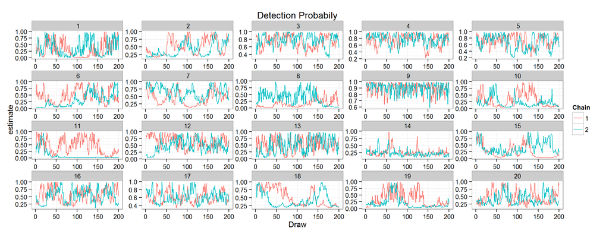

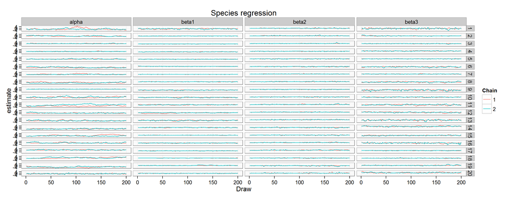

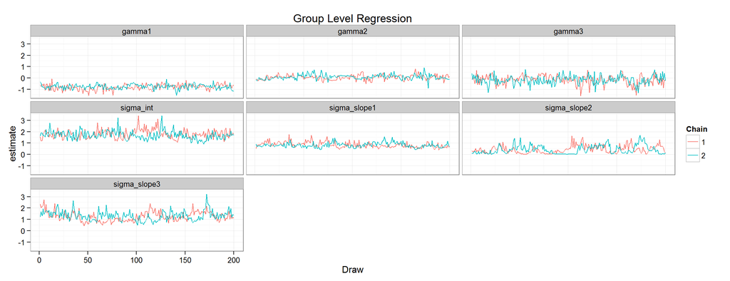

### Posteriors

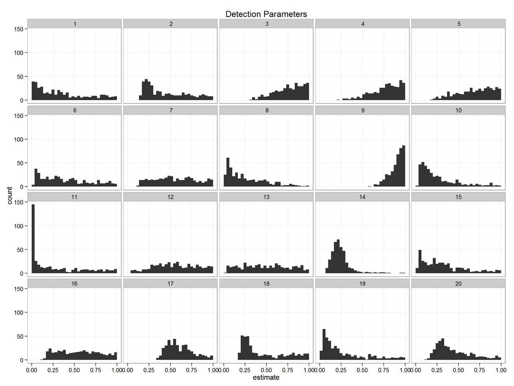

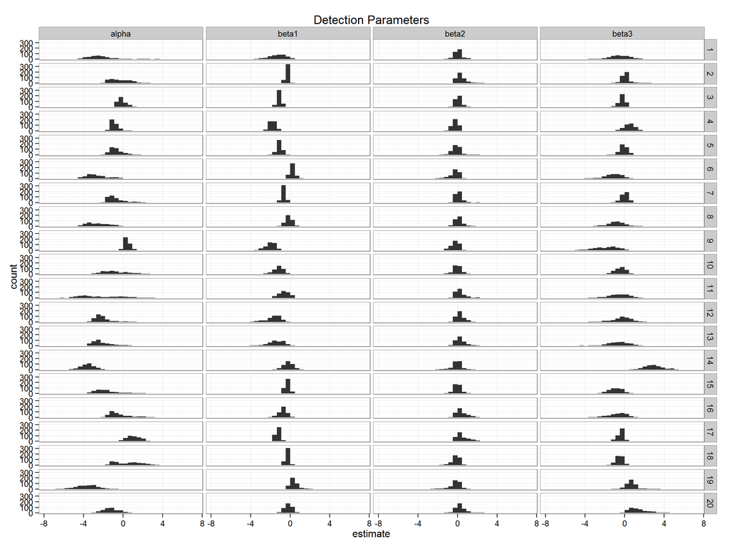

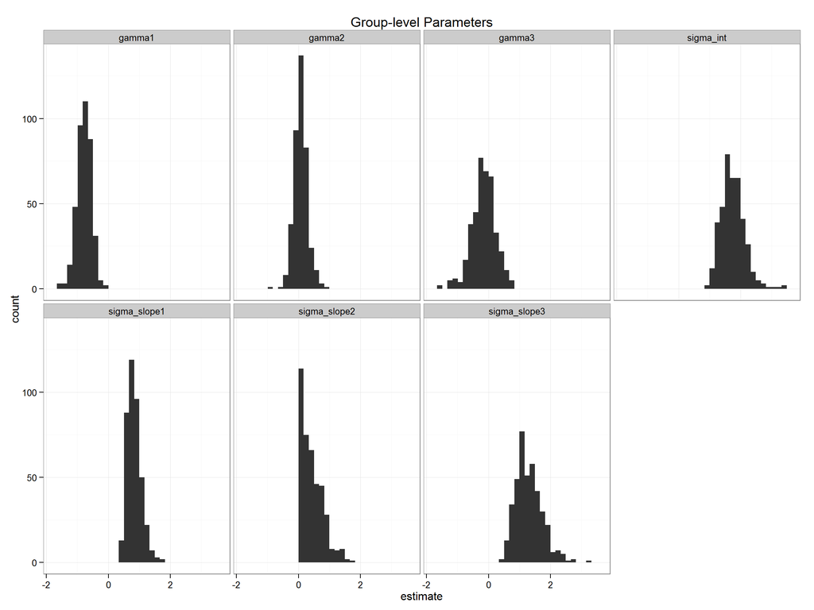

### Predicted Relationship

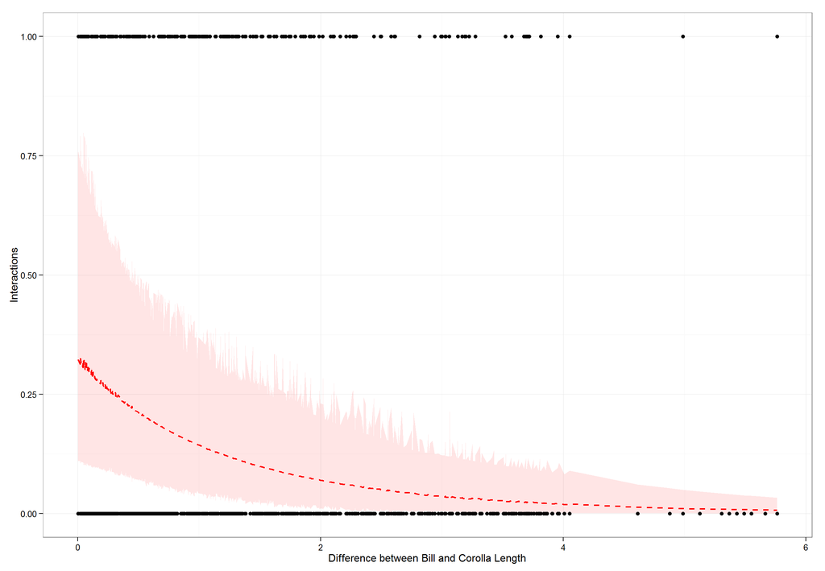

### Visualize interactions

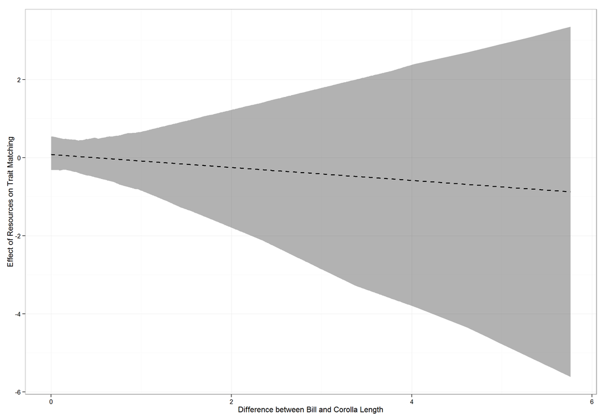

### Species Predictions

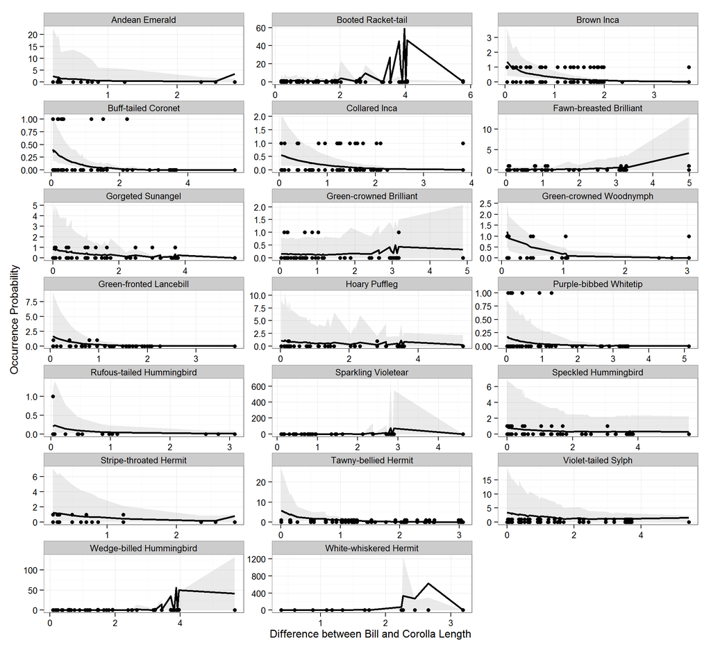

### Species Level Interaction

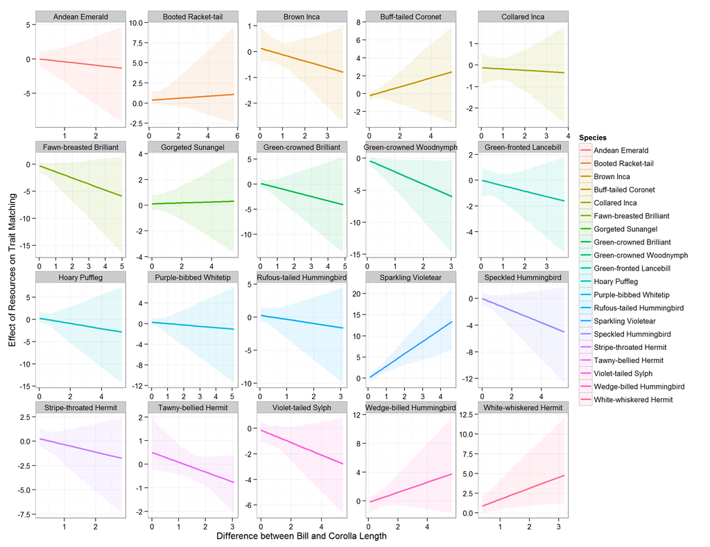

### Posterior Check

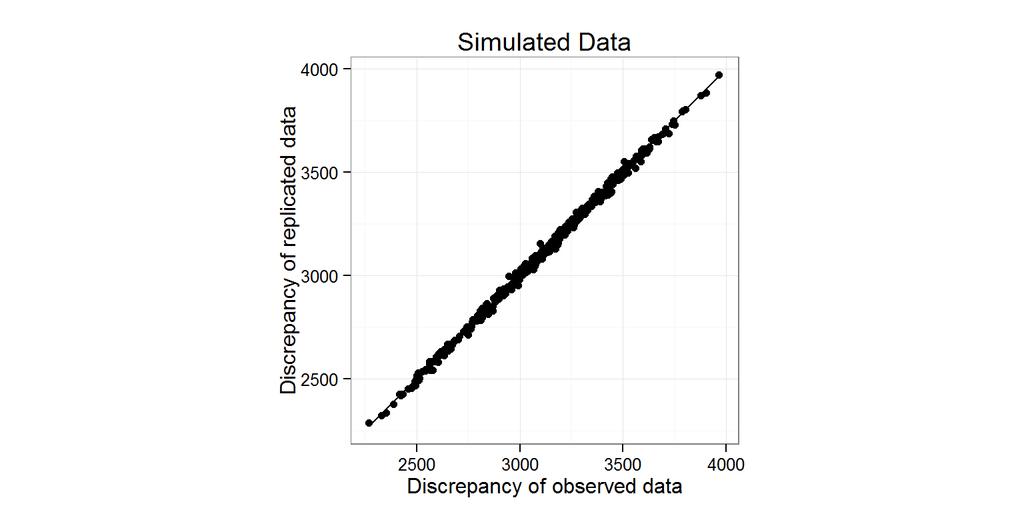